# Thực hành MANOVA: Dữ liệu nhân viên (DataEA)

Vũ Hà Thư - 25C23004

Hà

21/10/2026

**Phân công:** Vũ Hà Thư: câu (a)–(e); Hà: câu (f)–(g) và thuyết trình.

# 1 Câu hỏi nghiên cứu và quy ước

- **MANOVA một nhân tố:** Nhóm nhân viên đã nghỉ việc và nhóm đang làm việc có khác nhau khi xét đồng thời 9 đặc điểm về thu nhập – nghề nghiệp, kinh nghiệm làm việc và tâm lý – hành vi hay không?
- **MANOVA hai nhân tố:** Tình trạng nghỉ việc (`Attrition`) và việc làm thêm giờ (`OverTime`) có ảnh hưởng đến vectơ 4 biến tâm lý – hành vi không, và hai yếu tố này có tương tác với nhau không?

Toàn bài dùng mức ý nghĩa **α = 0.05** (độ tin cậy 95%), trừ khi ghi rõ mức khác.

**Quy ước mức độ vi phạm giả định** (dựa trên p-giá trị của kiểm định giả định): p ≥ 0.05 là **thỏa**; 1e-4 ≤ p < 0.05 là **vi phạm nhẹ**; p < 1e-4 là **vi phạm nặng**.

# 2 Câu (a): Dữ liệu và mô hình

## 2.1 Đọc dữ liệu

File `DataEA.xls` có đuôi .xls nhưng nội dung là văn bản phân tách bằng dấu phẩy (CSV, mã hóa UTF-8 có BOM), nên được đọc bằng `read.csv()`.

```r
ea_goc <- read.csv(here::here("data", "raw", "DataEA.xls"), fileEncoding = "UTF-8-BOM")
dim(ea_goc)
```

```
## [1] 1470   35
```

```r
str(ea_goc)
```

```
## 'data.frame':    1470 obs. of  35 variables:
##  $ Age                     : int  41 49 37 33 27 32 59 30 38 36 ...
##  $ Attrition               : chr  "Yes" "No" "Yes" "No" ...
##  $ BusinessTravel          : chr  "Travel_Rarely" "Travel_Frequently" "Travel_Rarely" "Travel_Frequently" ...
##  $ DailyRate               : int  1102 279 1373 1392 591 1005 1324 1358 216 1299 ...
##  $ Department              : chr  "Sales" "Research & Development" "Research & Development" "Research & Development" ...
##  $ DistanceFromHome        : int  1 8 2 3 2 2 3 24 23 27 ...
##  $ Education               : int  2 1 2 4 1 2 3 1 3 3 ...
##  $ EducationField          : chr  "Life Sciences" "Life Sciences" "Other" "Life Sciences" ...
##  $ EmployeeCount           : int  1 1 1 1 1 1 1 1 1 1 ...
##  $ EmployeeNumber          : int  1 2 4 5 7 8 10 11 12 13 ...
##  $ EnvironmentSatisfaction : int  2 3 4 4 1 4 3 4 4 3 ...
##  $ Gender                  : chr  "Female" "Male" "Male" "Female" ...
##  $ HourlyRate              : int  94 61 92 56 40 79 81 67 44 94 ...
##  $ JobInvolvement          : int  3 2 2 3 3 3 4 3 2 3 ...
```

[output cut: 21 more lines]

Dữ liệu có 1470 quan sát (mỗi quan sát là một nhân viên) và 35 biến.

## 2.2 Kiểm tra chất lượng dữ liệu

### 2.2.1 Dữ liệu thiếu và dữ liệu lặp

```r
# Số giá trị thiếu (NA hoặc chuỗi rỗng) trên toàn bộ dữ liệu
sum(is.na(ea_goc))
```

```
## [1] 0
```

```r
sum(ea_goc == "", na.rm = TRUE)
```

```
## [1] 0
```

```r
# Số dòng lặp hoàn toàn và số mã nhân viên bị trùng
sum(duplicated(ea_goc))
```

```
## [1] 0
```

```r
sum(duplicated(ea_goc$EmployeeNumber))
```

```
## [1] 0
```

**Nhận xét:** Không có giá trị thiếu hay chuỗi rỗng, không có dòng lặp và mỗi mã nhân viên (`EmployeeNumber`) chỉ xuất hiện một lần, nên mỗi dòng ứng với đúng một nhân viên và không cần loại hay điền khuyết.

### 2.2.2 Biến hằng

```r
so_gia_tri <- sapply(ea_goc, function(x) length(unique(x)))
so_gia_tri[so_gia_tri == 1]
```

```
## EmployeeCount        Over18 StandardHours
##             1             1             1
```

**Nhận xét:** `EmployeeCount` (luôn bằng 1), `Over18` (luôn là “Y”) và `StandardHours` (luôn bằng 80) không thay đổi giữa các nhân viên, nên không mang thông tin và không dùng trong phân tích.

### 2.2.3 Biến phân loại dùng làm nhân tố

```r
knitr::kable(table(ea_goc$Attrition), col.names = c("Attrition", "Số nhân viên"))
```

| Attrition | Số nhân viên |
| --- | --- |
| No | 1233 |
| Yes | 237 |

```r
knitr::kable(table(ea_goc$OverTime),  col.names = c("OverTime", "Số nhân viên"))
```

| OverTime | Số nhân viên |
| --- | --- |
| No | 1054 |
| Yes | 416 |

**Nhận xét:** Hai biến chỉ nhận đúng hai giá trị “No”/“Yes”, không có giá trị lỗi.

### 2.2.4 Miền giá trị và tính nhất quán của 9 biến định lượng

```r
bien <- c("MonthlyIncome", "JobLevel",
          "TotalWorkingYears", "YearsAtCompany", "YearsInCurrentRole",
          "JobSatisfaction", "EnvironmentSatisfaction", "WorkLifeBalance", "JobInvolvement")

# Giá trị nhỏ nhất, lớn nhất và số mức của từng biến
data.frame(bien = bien,
           nho_nhat = sapply(ea_goc[bien], min),
           lon_nhat = sapply(ea_goc[bien], max),
           so_muc   = sapply(ea_goc[bien], function(x) length(unique(x))),
           row.names = NULL)
```

| bien | nho_nhat | lon_nhat | so_muc |
| --- | --- | --- | --- |
| MonthlyIncome | 1009 | 19999 | 1349 |
| JobLevel | 1 | 5 | 5 |
| TotalWorkingYears | 0 | 40 | 40 |
| YearsAtCompany | 0 | 40 | 37 |
| YearsInCurrentRole | 0 | 18 | 19 |
| JobSatisfaction | 1 | 4 | 4 |
| EnvironmentSatisfaction | 1 | 4 | 4 |
| WorkLifeBalance | 1 | 4 | 4 |
| JobInvolvement | 1 | 4 | 4 |

```r
# Ràng buộc logic giữa các biến về thời gian (số dòng vi phạm)
data.frame(
  rang_buoc = c("YearsInCurrentRole <= YearsAtCompany",
                "YearsAtCompany <= TotalWorkingYears",
                "TotalWorkingYears < Age"),
  so_dong_vi_pham = c(sum(ea_goc$YearsInCurrentRole > ea_goc$YearsAtCompany),
                      sum(ea_goc$YearsAtCompany > ea_goc$TotalWorkingYears),
                      sum(ea_goc$TotalWorkingYears >= ea_goc$Age))
)
```

| rang_buoc | so_dong_vi_pham |
| --- | --- |
| YearsInCurrentRole <= YearsAtCompany | 0 |
| YearsAtCompany <= TotalWorkingYears | 0 |
| TotalWorkingYears < Age | 0 |

**Nhận xét:**

- 4 biến tâm lý – hành vi chỉ nhận các giá trị 1–4 và `JobLevel` nhận 1–5, đúng với thang đo; `MonthlyIncome` và 3 biến số năm đều không âm.
- Không có dòng nào vi phạm ràng buộc logic: số năm ở vị trí hiện tại không vượt số năm tại công ty, số năm tại công ty không vượt tổng số năm làm việc, và tổng số năm làm việc nhỏ hơn tuổi.
- `JobLevel` và 4 biến tâm lý – hành vi (5 biến) là **biến thứ bậc** có ít mức (4–5 mức), được xử lý như biến định lượng theo yêu cầu của đề.

### 2.2.5 Giá trị ngoại lai từng biến

Ngoại lai một chiều được xác định theo quy tắc boxplot của Tukey (*Exploratory Data Analysis*, 1977): giá trị nằm ngoài khoảng $[Q_1 - 1.5\,IQR;\ Q_3 + 1.5\,IQR]$, với $IQR = Q_3 - Q_1$.

```r
ngoai_lai_1c <- function(x) {
  q <- quantile(x, c(0.25, 0.75)); iqr <- q[2] - q[1]
  x < q[1] - 1.5 * iqr | x > q[2] + 1.5 * iqr
}
data.frame(bien = bien,
           so_ngoai_lai = sapply(ea_goc[bien], function(x) sum(ngoai_lai_1c(x))),
           ty_le_pct    = round(sapply(ea_goc[bien], function(x) mean(ngoai_lai_1c(x))) * 100, 1),
           do_lech      = round(sapply(ea_goc[bien], function(x) mean((x - mean(x))^3) / sd(x)^3), 2),
           row.names = NULL)
```

| bien | so_ngoai_lai | ty_le_pct | do_lech |
| --- | --- | --- | --- |
| MonthlyIncome | 114 | 7.8 | 1.37 |
| JobLevel | 0 | 0.0 | 1.02 |
| TotalWorkingYears | 63 | 4.3 | 1.11 |
| YearsAtCompany | 104 | 7.1 | 1.76 |
| YearsInCurrentRole | 21 | 1.4 | 0.92 |
| JobSatisfaction | 0 | 0.0 | -0.33 |
| EnvironmentSatisfaction | 0 | 0.0 | -0.32 |
| WorkLifeBalance | 0 | 0.0 | -0.55 |
| JobInvolvement | 0 | 0.0 | -0.50 |

**Nhận xét:** `MonthlyIncome` (114 giá trị, 7.8%), `YearsAtCompany` (104, 7.1%), `TotalWorkingYears` (63, 4.3%) và `YearsInCurrentRole` (21, 1.4%) có giá trị nằm ngoài khoảng trên, do các biến này lệch phải (hệ số bất đối xứng 0.92–1.76). Các giá trị này nằm trong miền hợp lệ (lương tối đa 19999, số năm tối đa 40, không vi phạm ràng buộc logic) và ứng với nhóm nhân viên có thu nhập hoặc thâm niên cao, nên được **giữ nguyên**: MANOVA so sánh vectơ trung bình, việc loại hay cắt (winsorize) các giá trị này sẽ làm thay đổi chính các trung bình cần so sánh. 5 biến thứ bậc không có ngoại lai. Ngoại lai nhiều chiều được xét ở câu (b).

## 2.3 Dữ liệu sau xử lý

```r
ea <- ea_goc[, c("EmployeeNumber", "Attrition", "OverTime", bien)]
ea$Attrition <- factor(ea$Attrition, levels = c("No", "Yes"))
ea$OverTime  <- factor(ea$OverTime,  levels = c("No", "Yes"))

# Ma trận dữ liệu cho MANOVA một nhân tố (9 biến) và hai nhân tố (4 biến tâm lý – hành vi)
X <- as.matrix(ea[, bien])
bien_tl <- c("JobSatisfaction", "EnvironmentSatisfaction", "WorkLifeBalance", "JobInvolvement")
Y <- as.matrix(ea[, bien_tl])

nhom <- ea$Attrition
X1 <- X[nhom == "No", ]    # nhân viên đang làm việc
X2 <- X[nhom == "Yes", ]   # nhân viên đã nghỉ việc
n  <- nrow(X); p <- ncol(X); g <- 2
n1 <- nrow(X1); n2 <- nrow(X2)
knitr::kable(t(c(n = n, p = p, n1 = n1, n2 = n2)))
```

| n | p | n1 | n2 |
| --- | --- | --- | --- |
| 1470 | 9 | 1233 | 237 |

```r
# 4 ô của mô hình hai nhân tố
o <- interaction(ea$Attrition, ea$OverTime, sep = ".")
knitr::kable(table(Attrition = ea$Attrition, OverTime = ea$OverTime))
```

|  | No | Yes |
| --- | --- | --- |
| No | 944 | 289 |
| Yes | 110 | 127 |

```r
# Lưu dữ liệu sạch dùng chung cho các câu sau
write.csv(ea, here::here("data", "processed", "DataEA_clean.csv"), row.names = FALSE)
```

Dữ liệu sạch gồm 1470 nhân viên, 2 nhân tố và 9 biến định lượng, được lưu tại `data/processed/DataEA_clean.csv` để dùng chung cho các câu sau. Cỡ mẫu **không cân bằng**: 1233 nhân viên đang làm việc và 237 nhân viên đã nghỉ việc; 4 ô Attrition × OverTime có cỡ mẫu: (No, No) = 944, (No, Yes) = 289, (Yes, No) = 110, (Yes, Yes) = 127. Trong các bảng sau, mỗi ô được ký hiệu `Attrition.OverTime`, ví dụ `Yes.No` là nhân viên đã nghỉ việc và không làm thêm giờ.

## 2.4 Mô hình phân tích

**Mô hình:** MANOVA một nhân tố với g = 2 tổng thể (Johnson & Wichern, mục 6.4). Với hai tổng thể, MANOVA một nhân tố tương đương kiểm định Hotelling $T^2$ so sánh hai vectơ trung bình (Johnson & Wichern, mục 6.3).

- **Biến độc lập (nhân tố):** `Attrition`, 2 mức: No (đang làm việc, $\ell = 1$), Yes (đã nghỉ việc, $\ell = 2$).
- **Vectơ biến phụ thuộc** (p = 9):

$$\mathbf X = \big(\underbrace{\text{MonthlyIncome},\
\text{JobLevel}}_{\text{thu nhập – nghề nghiệp}},\
\underbrace{\text{TotalWorkingYears},\ \text{YearsAtCompany},\
\text{YearsInCurrentRole}}_{\text{kinh nghiệm}},\
\underbrace{\text{JobSatisfaction},\ \text{EnvironmentSatisfaction},\
\text{WorkLifeBalance},\ \text{JobInvolvement}}_{\text{tâm lý – hành
vi}}\big)'$$

- **Mô hình:** $\mathbf X_{\ell j} = \boldsymbol\mu + \boldsymbol\tau_\ell + \mathbf e_{\ell j}$, $j = 1, \dots, n_\ell$, $\ell = 1, 2$, với $n_1\boldsymbol\tau_1 + n_2\boldsymbol\tau_2 = \mathbf 0$ và $\mathbf e_{\ell j} \sim N_9(\mathbf 0, \boldsymbol\Sigma)$ độc lập.

**Giả thuyết kiểm định tổng thể:**

$$\begin{aligned}
H_0 &: \boldsymbol\mu_1 = \boldsymbol\mu_2 \\
H_A &: \boldsymbol\mu_1 \neq \boldsymbol\mu_2
\end{aligned}$$

hay tương đương

$$\begin{aligned}
H_0 &: \boldsymbol\tau_1 = \boldsymbol\tau_2 = \mathbf 0 \\
H_A &: \text{tồn tại } \boldsymbol\tau_\ell \neq \mathbf 0
\end{aligned}$$

trong đó $\boldsymbol\mu_1$, $\boldsymbol\mu_2$ là vectơ trung bình của 9 biến ở nhóm đang làm việc và nhóm đã nghỉ việc.

**Các giả định của MANOVA** (Johnson & Wichern, mục 6.4): (1) các mẫu độc lập với nhau và các quan sát trong mỗi mẫu độc lập; (2) mỗi tổng thể có phân phối chuẩn nhiều chiều; (3) các tổng thể có cùng ma trận hiệp phương sai $\boldsymbol\Sigma_1 = \boldsymbol\Sigma_2$. Giả định (1) được đảm bảo theo cách thu thập dữ liệu (mỗi dòng là một nhân viên khác nhau); giả định (2) và (3) được kiểm tra ở câu (b).

# 3 Câu (b): Kiểm tra giả định

Giả định được kiểm tra cho cả hai mô hình:

- **MANOVA một nhân tố:** 9 biến, trong từng nhóm `Attrition` (2 nhóm).
- **MANOVA hai nhân tố:** 4 biến tâm lý – hành vi, trong từng ô `Attrition × OverTime` (4 ô), vì mô hình hai nhân tố giả định mỗi ô là một tổng thể chuẩn 4 chiều và các ô có cùng ma trận hiệp phương sai.

## 3.1 Thống kê mô tả

```r
# Trung bình và độ lệch chuẩn theo nhóm Attrition
mo_ta <- data.frame(
  bien     = bien,
  tb_No    = round(colMeans(X1), 2),
  dlc_No   = round(apply(X1, 2, sd), 2),
  tb_Yes   = round(colMeans(X2), 2),
  dlc_Yes  = round(apply(X2, 2, sd), 2),
  row.names = NULL
)
mo_ta
```

| bien | tb_No | dlc_No | tb_Yes | dlc_Yes |
| --- | --- | --- | --- | --- |
| MonthlyIncome | 6832.74 | 4818.21 | 4787.09 | 3640.21 |
| JobLevel | 2.15 | 1.12 | 1.64 | 0.94 |
| TotalWorkingYears | 11.86 | 7.76 | 8.24 | 7.17 |
| YearsAtCompany | 7.37 | 6.10 | 5.13 | 5.95 |
| YearsInCurrentRole | 4.48 | 3.65 | 2.90 | 3.17 |
| JobSatisfaction | 2.78 | 1.09 | 2.47 | 1.12 |
| EnvironmentSatisfaction | 2.77 | 1.07 | 2.46 | 1.17 |
| WorkLifeBalance | 2.78 | 0.68 | 2.66 | 0.82 |
| JobInvolvement | 2.77 | 0.69 | 2.52 | 0.77 |

```r
# Trung bình 4 biến tâm lý – hành vi theo 4 ô
aggregate(Y, by = list(Attrition = ea$Attrition, OverTime = ea$OverTime), FUN = function(x) round(mean(x), 2))
```

| Attrition | OverTime | JobSatisfaction | EnvironmentSatisfaction | WorkLifeBalance | JobInvolvement |
| --- | --- | --- | --- | --- | --- |
| No | No | 2.75 | 2.71 | 2.79 | 2.76 |
| Yes | No | 2.36 | 2.33 | 2.63 | 2.48 |
| No | Yes | 2.87 | 2.96 | 2.75 | 2.80 |
| Yes | Yes | 2.56 | 2.58 | 2.69 | 2.55 |

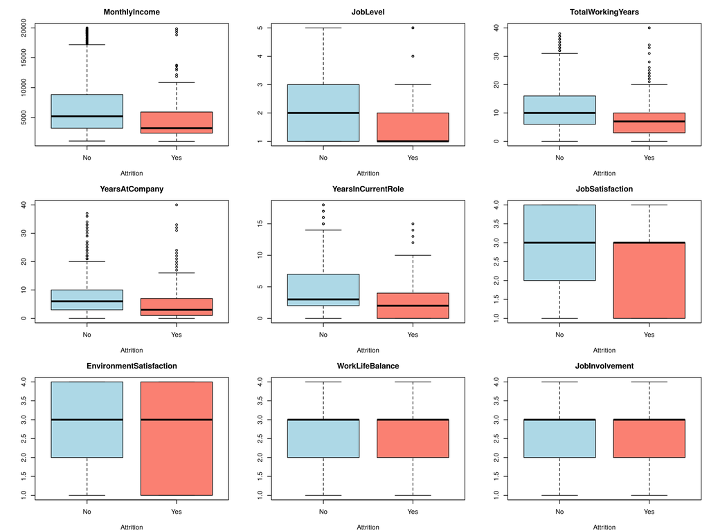

```r
par(mfrow = c(3, 3), mar = c(4, 4.5, 3, 1))
for (v in bien) {
  boxplot(ea[[v]] ~ ea$Attrition, col = c("lightblue", "salmon"),
          main = v, xlab = "Attrition", ylab = "")
}
```

```r
par(mfrow = c(1, 1))
```

**Nhận xét:**

- Nhóm đã nghỉ việc có trung bình **thấp hơn ở cả 9 biến**: thu nhập 4787 so với 6833; cấp bậc 1.64 so với 2.15; tổng số năm làm việc 8.24 so với 11.86; số năm tại công ty 5.13 so với 7.37; số năm ở vị trí hiện tại 2.90 so với 4.48.
- Bốn biến tâm lý – hành vi của nhóm nghỉ việc thấp hơn 0.12–0.31 điểm (trên thang 1–4): hài lòng công việc 2.47 so với 2.78, hài lòng môi trường 2.46 so với 2.77, cân bằng công việc – cuộc sống 2.66 so với 2.78, mức độ tham gia công việc 2.52 so với 2.77.
- Theo ô: ở cả hai mức `OverTime`, nhóm nghỉ việc có điểm tâm lý – hành vi thấp hơn nhóm đang làm việc; ví dụ hài lòng công việc 2.36 so với 2.75 (không làm thêm giờ) và 2.56 so với 2.87 (có làm thêm giờ).
- Boxplot cho thấy thu nhập và các biến số năm lệch phải với nhiều điểm nằm ngoài râu, còn các biến thứ bậc chỉ nhận vài giá trị rời rạc.

## 3.2 Ngoại lai nhiều chiều (khoảng cách Mahalanobis)

Với mỗi nhóm, tính bình phương khoảng cách Mahalanobis của từng quan sát đến vectơ trung bình mẫu của nhóm:

$$d_j^2 = (\mathbf x_j - \bar{\mathbf
x})' \mathbf S^{-1} (\mathbf x_j - \bar{\mathbf x}).$$

Nếu dữ liệu có phân phối chuẩn p chiều thì $d_j^2$ có phân phối xấp xỉ $\chi^2_p$. Với mỗi quan sát, kiểm định giả thuyết

$$\begin{aligned}
H_0 &: \text{quan sát } j \text{ không phải ngoại lai} \\
H_A &: \text{quan sát } j \text{ là ngoại lai}
\end{aligned}$$

Theo Johnson & Wichern (mục 4.7), $d_j^2$ “lớn” được đánh giá bằng một phân vị của phân phối $\chi^2_p$; vì ngay cả khi dữ liệu chuẩn vẫn có khoảng 5% số quan sát vượt phân vị 95%, nên cần dùng một phân vị cực trị hơn. Bài này chọn mức ý nghĩa α = 0.001, tức bác bỏ $H_0$ khi $d_j^2 > \chi^2_p(0.999)$.

```r
# Hàm tính d2 trong từng nhóm
d2_theo_nhom <- function(M, f) {
  d2 <- numeric(nrow(M))
  for (l in levels(f)) {
    i <- which(f == l)
    d2[i] <- mahalanobis(M[i, ], colMeans(M[i, ]), cov(M[i, ]))
  }
  d2
}
bang_ngoai_lai <- function(d2, f, df) {
  nguong <- qchisq(0.999, df = df)
  data.frame(nhom = levels(f),
             n = as.vector(table(f)),
             d2_lon_nhat = round(tapply(d2, f, max), 2),
             p_value = fp(pchisq(tapply(d2, f, max), df = df, lower.tail = FALSE)),
             nguong = round(nguong, 2),
             so_ngoai_lai = as.vector(tapply(d2 > nguong, f, sum)),
             row.names = NULL)
}

# MANOVA một nhân tố: 9 biến, theo Attrition
d2_A <- d2_theo_nhom(X, nhom)
bang_ngoai_lai(d2_A, nhom, df = 9)
```

| nhom | n | d2_lon_nhat | p_value | nguong | so_ngoai_lai |
| --- | --- | --- | --- | --- | --- |
| No | 1233 | 54.21 | 1.72e-08 | 27.88 | 17 |
| Yes | 237 | 62.79 | 3.87e-10 | 27.88 | 6 |

```r
# MANOVA hai nhân tố: 4 biến tâm lý – hành vi, theo 4 ô
d2_B <- d2_theo_nhom(Y, o)
bang_ngoai_lai(d2_B, o, df = 4)
```

| nhom | n | d2_lon_nhat | p_value | nguong | so_ngoai_lai |
| --- | --- | --- | --- | --- | --- |
| No.No | 944 | 15.25 | 0.00421 | 18.47 | 0 |
| Yes.No | 110 | 9.69 | 0.0459 | 18.47 | 0 |
| No.Yes | 289 | 11.67 | 0.02 | 18.47 | 0 |
| Yes.Yes | 127 | 10.55 | 0.0321 | 18.47 | 0 |

```r
# Thông tin các quan sát ngoại lai của mô hình một nhân tố
ngoai_lai_A <- which(d2_A > qchisq(0.999, df = 9))
data.frame(dong = ngoai_lai_A, ea[ngoai_lai_A, c("EmployeeNumber", "Attrition", bien)],
           d2 = round(d2_A[ngoai_lai_A], 2), row.names = NULL)
```

| dong | EmployeeNumber | Attrition | MonthlyIncome | JobLevel | TotalWorkingYears | YearsAtCompany | YearsInCurrentRole | JobSatisfaction | EnvironmentSatisfaction | WorkLifeBalance | JobInvolvement | d2 |
| --- | --- | --- | --- | --- | --- | --- | --- | --- | --- | --- | --- | --- |
| 34 | 42 | Yes | 2086 | 2 | 19 | 1 | 0 | 4 | 4 | 4 | 3 | 32.09 |
| 51 | 64 | Yes | 5381 | 3 | 23 | 1 | 0 | 3 | 1 | 3 | 2 | 32.60 |
| 63 | 80 | No | 18740 | 5 | 29 | 27 | 3 | 3 | 2 | 2 | 2 | 31.30 |
| 86 | 112 | No | 7260 | 3 | 37 | 6 | 4 | 4 | 4 | 2 | 1 | 42.69 |
| 99 | 131 | No | 13872 | 4 | 38 | 37 | 10 | 3 | 4 | 2 | 3 | 41.98 |
| 127 | 165 | Yes | 10312 | 3 | 40 | 40 | 10 | 4 | 4 | 2 | 3 | 62.79 |
| 238 | 329 | No | 19068 | 5 | 33 | 33 | 7 | 3 | 1 | 4 | 2 | 38.09 |
| 245 | 336 | No | 19202 | 5 | 25 | 24 | 0 | 4 | 3 | 3 | 4 | 40.54 |
| 271 | 374 | No | 19045 | 5 | 37 | 36 | 10 | 1 | 4 | 3 | 3 | 35.51 |
| 312 | 425 | No | 5210 | 3 | 24 | 24 | 9 | 1 | 1 | 3 | 3 | 28.58 |
| 412 | 549 | No | 19566 | 5 | 33 | 29 | 8 | 1 | 1 | 1 | 3 | 30.81 |
| 478 | 644 | No | 18200 | 5 | 32 | 32 | 5 | 2 | 1 | 3 | 3 | 38.38 |
| 562 | 776 | No | 16856 | 4 | 34 | 34 | 6 | 1 | 3 | 4 | 2 | 47.34 |
| 569 | 787 | Yes | 19859 | 5 | 24 | 5 | 2 | 1 | 4 | 3 | 3 | 37.27 |
| 654 | 905 | No | 17924 | 4 | 31 | 31 | 6 | 1 | 1 | 3 | 3 | 38.36 |
| 750 | 1038 | Yes | 19845 | 5 | 33 | 32 | 14 | 4 | 1 | 3 | 1 | 31.03 |
| 915 | 1278 | No | 13577 | 4 | 34 | 33 | 9 | 2 | 4 | 3 | 2 | 31.23 |
| 963 | 1352 | No | 14026 | 4 | 33 | 33 | 9 | 2 | 3 | 3 | 3 | 28.43 |
| 1087 | 1539 | No | 14411 | 4 | 32 | 32 | 6 | 4 | 3 | 3 | 1 | 39.66 |
| 1112 | 1572 | Yes | 10169 | 3 | 34 | 33 | 7 | 4 | 3 | 3 | 2 | 45.83 |
| 1117 | 1578 | No | 19586 | 5 | 36 | 36 | 6 | 4 | 3 | 3 | 2 | 46.31 |
| 1136 | 1602 | No | 17567 | 4 | 27 | 26 | 0 | 1 | 4 | 1 | 4 | 54.21 |
| 1139 | 1606 | No | 11245 | 4 | 32 | 30 | 8 | 3 | 2 | 3 | 3 | 29.31 |

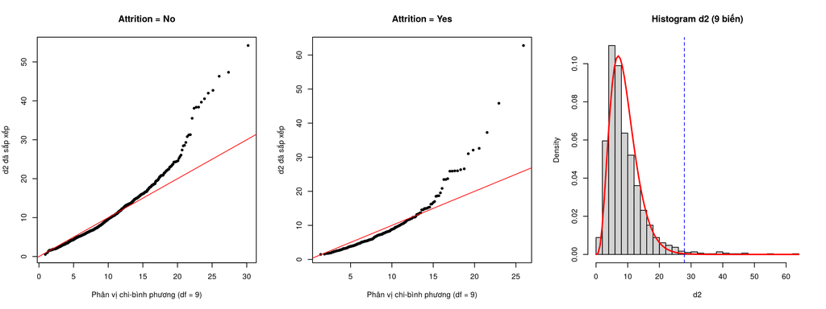

```r
par(mfrow = c(1, 3))
for (l in levels(nhom)) {
  d2 <- sort(d2_A[nhom == l]); m <- length(d2)
  plot(qchisq(((1:m) - 0.5) / m, df = 9), d2, pch = 19, cex = 0.6,
       main = paste("Attrition =", l), xlab = "Phân vị chi-bình phương (df = 9)", ylab = "d2 đã sắp xếp")
  abline(0, 1, col = "red")
}
hist(d2_A, freq = FALSE, breaks = 40, main = "Histogram d2 (9 biến)", xlab = "d2")
curve(dchisq(x, df = 9), add = TRUE, col = "red", lwd = 2)
abline(v = qchisq(0.999, df = 9), col = "blue", lty = 2)
```

```r
par(mfrow = c(1, 1))
```

**Nhận xét:**

- **Một nhân tố** (9 biến, ngưỡng $\chi^2_9(0.999) = 27.88$): nhóm No có 17 quan sát vượt ngưỡng ($d^2$ lớn nhất 54.21, p-giá trị = 1.72e-08), nhóm Yes có 6 quan sát ($d^2$ lớn nhất 62.79, p-giá trị = 3.87e-10). Với 23 quan sát này, p-giá trị < 0.001 nên ta bác bỏ $H_0$ với mức ý nghĩa 0.1%, nghĩa là đây là các quan sát ngoại lai nhiều chiều (1.6% mẫu).
- Phần lớn các quan sát này là nhân viên có thâm niên rất dài (tổng số năm làm việc 24–40), nhiều người có thu nhập và cấp bậc cao (cấp 4–5); số còn lại có có tổ hợp ít gặp như nhiều năm kinh nghiệm nhưng mới vào công ty (dòng 34 và 51: 19 và 23 năm làm việc, 1 năm tại công ty). Mọi giá trị đều hợp lệ và thỏa ràng buộc logic ở câu (a), nên các quan sát được **giữ lại**.
- Biểu đồ chi-bình phương: các điểm lệch lên khỏi đường thẳng ở phần đuôi phải, nghĩa là phân phối có đuôi nặng hơn chuẩn, phù hợp với tính lệch phải của thu nhập và số năm làm việc.
- **Hai nhân tố** (4 biến tâm lý – hành vi, ngưỡng $\chi^2_4(0.999) = 18.47$): $d^2$ lớn nhất trong 4 ô từ 9.69 đến 15.25 (p-giá trị 0.0042–0.0459 > 0.001) nên ta không bác bỏ $H_0$, nghĩa là không có quan sát ngoại lai.

## 3.3 Chuẩn từng biến (Shapiro-Wilk)

Với mỗi biến trong mỗi nhóm (hoặc mỗi ô), kiểm định giả thuyết

$$\begin{aligned}
H_0 &: \text{biến có phân phối chuẩn} \\
H_A &: \text{biến không có phân phối chuẩn}
\end{aligned}$$

```r
# MANOVA một nhân tố: 9 biến x 2 nhóm
bang_shapiro_A <- sapply(levels(nhom), function(l)
  apply(X[nhom == l, ], 2, function(x) shapiro.test(x)$p.value))
knitr::kable(apply(bang_shapiro_A, 2, fp))
```

|  | No | Yes |
| --- | --- | --- |
| MonthlyIncome | 5.97e-34 | 1.5e-17 |
| JobLevel | 6.63e-34 | 2.72e-20 |
| TotalWorkingYears | 2.1e-26 | 2.07e-14 |
| YearsAtCompany | 1.67e-32 | 1.3e-19 |
| YearsInCurrentRole | 8.44e-27 | 6.26e-16 |
| JobSatisfaction | 2.88e-33 | 2.31e-14 |
| EnvironmentSatisfaction | 1.05e-32 | 4.69e-15 |
| WorkLifeBalance | 5.99e-37 | 4.84e-15 |
| JobInvolvement | 3.59e-36 | 7.93e-16 |

```r
# MANOVA hai nhân tố: 4 biến x 4 ô
bang_shapiro_B <- sapply(levels(o), function(l)
  apply(Y[o == l, ], 2, function(x) shapiro.test(x)$p.value))
knitr::kable(apply(bang_shapiro_B, 2, fp))
```

|  | No.No | Yes.No | No.Yes | Yes.Yes |
| --- | --- | --- | --- | --- |
| JobSatisfaction | 4.92e-29 | 1.52e-09 | 7.77e-18 | 1.03e-09 |
| EnvironmentSatisfaction | 6.13e-29 | 4.12e-10 | 1.16e-16 | 2.14e-10 |
| WorkLifeBalance | 7.59e-33 | 4.86e-09 | 2.61e-19 | 2.77e-11 |
| JobInvolvement | 2.92e-32 | 5.46e-10 | 2e-18 | 2.26e-11 |

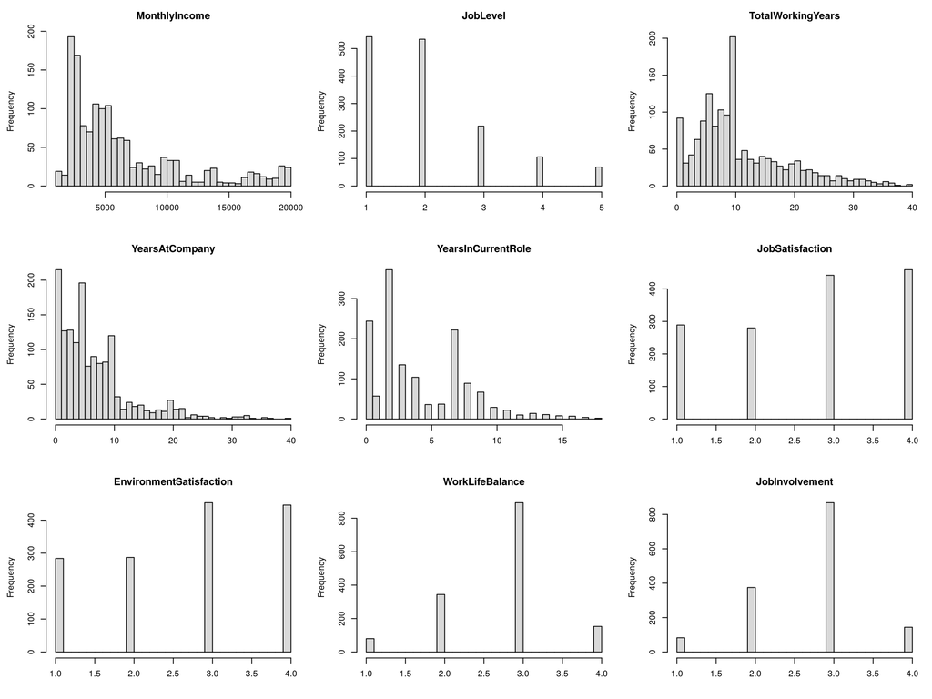

```r
par(mfrow = c(3, 3), mar = c(4, 4.5, 3, 1))
for (v in bien) hist(ea[[v]], breaks = 30, main = v, xlab = "", col = "grey85")
```

```r
par(mfrow = c(1, 1))
```

**Nhận xét:** Ở cả 18 trường hợp của mô hình một nhân tố (p-giá trị lớn nhất 2.31e-14) và 16 trường hợp của mô hình hai nhân tố (p-giá trị lớn nhất 4.86e-09), p-giá trị < 0.05 nên ta bác bỏ $H_0$ với mức ý nghĩa 5%, nghĩa là không biến nào có phân phối chuẩn trong nhóm (ô); p-giá trị < 1e-4 nên đây là **vi phạm nặng**. Histogram cho thấy nguyên nhân: 5 biến thứ bậc chỉ nhận 4–5 giá trị rời rạc, còn thu nhập và các biến số năm lệch phải.

## 3.4 Chuẩn nhiều chiều (mshapiro_test)

Với mỗi nhóm (hoặc mỗi ô), kiểm định giả thuyết

$$\begin{aligned}
H_0 &: \text{vectơ biến phụ thuộc có phân phối chuẩn nhiều chiều} \\
H_A &: \text{vectơ biến phụ thuộc không có phân phối chuẩn nhiều
chiều}
\end{aligned}$$

```r
bang_mshapiro <- function(M, f) {
  kq <- data.frame(nhom = levels(f), statistic = NA, p_value = NA)
  for (k in seq_along(levels(f))) {
    ms <- mshapiro_test(as.data.frame(M[f == levels(f)[k], ]))
    kq$statistic[k] <- round(ms$statistic, 4)
    kq$p_value[k]   <- ms$p.value
  }
  kq
}
bang_mshapiro_A <- bang_mshapiro(X, nhom)   # 9 biến, theo Attrition
transform(bang_mshapiro_A, p_value = fp(p_value))
```

| nhom | statistic | p_value |
| --- | --- | --- |
| No | 0.9008 | 1.61e-27 |
| Yes | 0.6737 | 3.98e-21 |

```r
bang_mshapiro_B <- bang_mshapiro(Y, o)      # 4 biến tâm lý – hành vi, theo 4 ô
transform(bang_mshapiro_B, p_value = fp(p_value))
```

| nhom | statistic | p_value |
| --- | --- | --- |
| No.No | 0.9931 | 0.000217 |
| Yes.No | 0.9896 | 0.566 |
| No.Yes | 0.9875 | 0.0134 |
| Yes.Yes | 0.9675 | 0.00377 |

**Nhận xét:**

- **Một nhân tố:** nhóm No (p-giá trị = 1.61e-27) và nhóm Yes (p-giá trị = 3.98e-21) có p-giá trị < 0.05 nên ta bác bỏ $H_0$ với mức ý nghĩa 5%, nghĩa là vectơ 9 biến không có phân phối chuẩn nhiều chiều; p-giá trị < 1e-4 nên đây là vi phạm nặng.
- **Hai nhân tố:** ô `Yes.No` có p-giá trị = 0.566 > 0.05 nên ta không bác bỏ $H_0$, nghĩa là chưa có cơ sở cho rằng vectơ 4 biến trong ô này không chuẩn. Ba ô `No.No` (p-giá trị = 0.000217), `No.Yes` (0.0134) và `Yes.Yes` (0.00377) có p-giá trị < 0.05 nên ta bác bỏ $H_0$ với mức ý nghĩa 5%; p-giá trị > 1e-4 nên đây là vi phạm nhẹ.

## 3.5 Tương quan và đa cộng tuyến giữa các biến phụ thuộc

Việc xét đồng thời các biến bằng MANOVA có ý nghĩa khi các biến phụ thuộc có tương quan với nhau; đồng thời các biến không được có đa cộng tuyến để ma trận phần dư $\mathbf W$ khả nghịch.

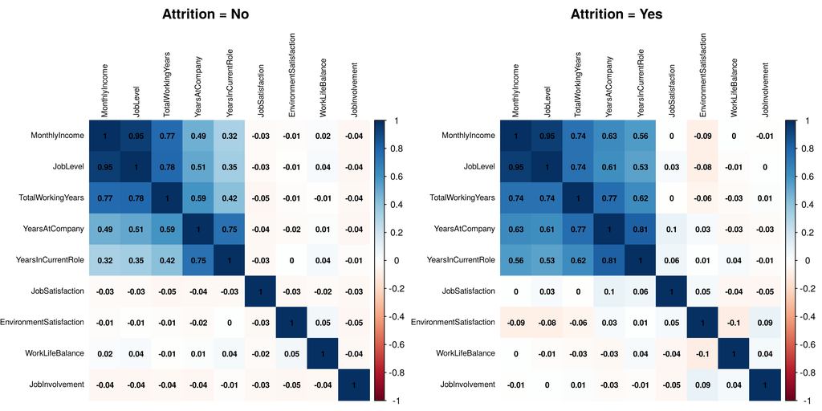

```r
par(mfrow = c(1, 2))
corrplot(cor(X1), method = "color", addCoef.col = "black", tl.col = "black",
         col.lim = c(-1, 1), number.cex = 0.7, tl.cex = 0.7,
         title = "Attrition = No", mar = c(0, 0, 2, 0))
corrplot(cor(X2), method = "color", addCoef.col = "black", tl.col = "black",
         col.lim = c(-1, 1), number.cex = 0.7, tl.cex = 0.7,
         title = "Attrition = Yes", mar = c(0, 0, 2, 0))
```

```r
par(mfrow = c(1, 1))
```

**Kiểm tra đa cộng tuyến bằng VIF.** VIF được tính trên ma trận tương quan gộp trong nhóm $\mathbf R_{pooled}$, chuẩn hóa từ ma trận phần dư $\mathbf W = \sum_\ell (n_\ell - 1)\mathbf S_\ell$:

$$VIF_j = \left[\mathbf
R_{pooled}^{-1}\right]_{jj} = \frac{1}{1 - R_j^2},$$

với $R_j^2$ là hệ số xác định khi hồi quy biến j theo các biến còn lại (trong nhóm). Johnson & Wichern không đưa ra ngưỡng cho VIF; trong hồi quy, ngưỡng kinh nghiệm thường dùng là VIF vượt 5 hoặc 10 thì đa cộng tuyến đáng kể (James và cộng sự, *An Introduction to Statistical Learning*, 2013, mục 3.3.3). Bài này đọc VIF trực tiếp qua $R_j^2 = 1 - 1/VIF_j$ và dùng ngưỡng 5 để đối chiếu.

```r
# MANOVA một nhân tố: 9 biến
W_A <- (n1 - 1) * cov(X1) + (n2 - 1) * cov(X2)
R_pooled_A <- cov2cor(W_A)
vif_A <- diag(solve(R_pooled_A))
knitr::kable(data.frame(bien = bien, VIF = round(vif_A, 2), R2 = round(1 - 1 / vif_A, 3), row.names = NULL))
```

| bien | VIF | R2 |
| --- | --- | --- |
| MonthlyIncome | 10.35 | 0.903 |
| JobLevel | 10.76 | 0.907 |
| TotalWorkingYears | 3.07 | 0.674 |
| YearsAtCompany | 3.05 | 0.672 |
| YearsInCurrentRole | 2.34 | 0.572 |
| JobSatisfaction | 1.00 | 0.004 |
| EnvironmentSatisfaction | 1.00 | 0.002 |
| WorkLifeBalance | 1.01 | 0.008 |
| JobInvolvement | 1.01 | 0.005 |

```r
det(R_pooled_A)
```

```
## [1] 0.009980999
```

```r
# MANOVA hai nhân tố: 4 biến tâm lý – hành vi, tương quan gộp trong ô
E_B <- crossprod(resid(lm(Y ~ Attrition * OverTime, data = ea)))
R_pooled_B <- cov2cor(E_B)
knitr::kable(round(R_pooled_B, 3))
```

|  | JobSatisfaction | EnvironmentSatisfaction | WorkLifeBalance | JobInvolvement |
| --- | --- | --- | --- | --- |
| JobSatisfaction | 1.000 | -0.023 | -0.026 | -0.037 |
| EnvironmentSatisfaction | -0.023 | 1.000 | 0.022 | -0.025 |
| WorkLifeBalance | -0.026 | 0.022 | 1.000 | -0.023 |
| JobInvolvement | -0.037 | -0.025 | -0.023 | 1.000 |

```r
vif_B <- diag(solve(R_pooled_B))
knitr::kable(data.frame(bien = bien_tl, VIF = round(vif_B, 2), R2 = round(1 - 1 / vif_B, 3), row.names = NULL))
```

| bien | VIF | R2 |
| --- | --- | --- |
| JobSatisfaction | 1 | 0.003 |
| EnvironmentSatisfaction | 1 | 0.002 |
| WorkLifeBalance | 1 | 0.002 |
| JobInvolvement | 1 | 0.003 |

```r
det(R_pooled_B)
```

```
## [1] 0.9957218
```

**Nhận xét:**

- **Tương quan (một nhân tố):** trong mỗi nhóm, 5 biến thu nhập và kinh nghiệm tương quan dương với nhau (r từ 0.32 đến 0.95 ở nhóm No, từ 0.53 đến 0.95 ở nhóm Yes), mạnh nhất là `MonthlyIncome` – `JobLevel` (r ≈ 0.95). 4 biến tâm lý – hành vi gần như không tương quan với nhau và với các biến khác (|r| ≤ 0.05 ở nhóm No, ≤ 0.10 ở nhóm Yes).
- **VIF (một nhân tố):** `MonthlyIncome` (VIF = 10.35) và `JobLevel` (10.76) có $R_j^2 \approx 0.90$, tức mỗi biến được giải thích khoảng 90% bởi các biến còn lại, vượt ngưỡng kinh nghiệm 5 và 10: hai biến này có **đa cộng tuyến đáng kể** (mức lương gắn chặt với cấp bậc). 3 biến kinh nghiệm có VIF 2.34–3.07 ($R_j^2$ 0.57–0.67); 4 biến tâm lý – hành vi có VIF ≈ 1. $\det(\mathbf R_{pooled}) = 0.0100$ nhỏ nhưng khác 0, nên $\mathbf W$ vẫn khả nghịch và các thống kê MANOVA tính được. Đề yêu cầu giữ cả hai biến trong vectơ phụ thuộc; ảnh hưởng của cặp biến này được kiểm tra bằng phân tích độ nhạy ở câu (c).
- **Hai nhân tố:** tương quan gộp trong ô giữa 4 biến tâm lý – hành vi chỉ từ −0.037 đến 0.022, VIF = 1.00 và $\det(\mathbf R_{pooled}) = 0.996$, nên không có đa cộng tuyến. Mặt khác, vì các biến gần như không tương quan, việc xét đồng thời 4 biến bằng MANOVA mang thêm ít thông tin so với phân tích riêng từng biến.

## 3.6 Đồng nhất ma trận hiệp phương sai (Box’s M)

**MANOVA một nhân tố**, kiểm định giả thuyết

$$\begin{aligned}
H_0 &: \boldsymbol\Sigma_1 = \boldsymbol\Sigma_2 = \boldsymbol\Sigma
\\
H_A &: \boldsymbol\Sigma_1 \neq \boldsymbol\Sigma_2
\end{aligned}$$

**MANOVA hai nhân tố**, kiểm định giả thuyết

$$\begin{aligned}
H_0 &: \boldsymbol\Sigma_{11} = \boldsymbol\Sigma_{12} =
\boldsymbol\Sigma_{21} = \boldsymbol\Sigma_{22} = \boldsymbol\Sigma \\
H_A &: \text{có ít nhất hai ô có ma trận hiệp phương sai khác nhau}
\end{aligned}$$

Thống kê $C = (1-u)M$ có phân phối xấp xỉ $\chi^2_\nu$ với $\nu = \frac12 p(p+1)(g-1)$ bậc tự do; bác bỏ $H_0$ khi $C > \chi^2_\nu(1-\alpha)$ (Johnson & Wichern, mục 6.6). Mô hình một nhân tố có p = 9, g = 2 nên $\nu = 45$; mô hình hai nhân tố có p = 4 biến và 4 ô nên $\nu = 30$. Theo Johnson & Wichern, xấp xỉ này tốt khi mỗi $n_\ell > 20$ và $p, g \le 5$. Mô hình hai nhân tố thỏa các điều kiện này (ô nhỏ nhất có 110 quan sát); mô hình một nhân tố có p = 9 > 5 nên xấp xỉ kém chính xác hơn.

```r
box_m_A <- box_m(as.data.frame(X), nhom)
box_m_A
```

| statistic | p.value | parameter | method |
| --- | --- | --- | --- |
| 174.1199 | 0 | 45 | Box’s M-test for Homogeneity of Covariance Matrices |

```r
qchisq(0.95, df = 45)   # phân vị chi2_45(0.95)
```

```
## [1] 61.65623
```

```r
box_m_B <- box_m(as.data.frame(Y), o)
box_m_B
```

| statistic | p.value | parameter | method |
| --- | --- | --- | --- |
| 54.74621 | 0.0037921 | 30 | Box’s M-test for Homogeneity of Covariance Matrices |

```r
qchisq(0.95, df = 30)   # phân vị chi2_30(0.95)
```

```
## [1] 43.77297
```

## 3.7 Đồng nhất phương sai từng biến (Levene)

Với mỗi biến, kiểm định giả thuyết

$$\begin{aligned}
H_0 &: \text{phương sai của biến bằng nhau giữa các nhóm (các ô)} \\
H_A &: \text{có ít nhất hai nhóm (ô) có phương sai khác nhau}
\end{aligned}$$

```r
ea_dai <- pivot_longer(ea, cols = all_of(bien), names_to = "bien", values_to = "gia_tri")

# MANOVA một nhân tố: 9 biến, theo Attrition
bang_levene_A <- levene_test(group_by(ea_dai, bien), gia_tri ~ Attrition)
bang_levene_A <- bang_levene_A[match(bien, bang_levene_A$bien), ]
bang_levene_A
```

| bien | df1 | df2 | statistic | p |
| --- | --- | --- | --- | --- |
| MonthlyIncome | 1 | 1468 | 14.899587 | 0.0001183 |
| JobLevel | 1 | 1468 | 7.285488 | 0.0070311 |
| TotalWorkingYears | 1 | 1468 | 3.062385 | 0.0803329 |
| YearsAtCompany | 1 | 1468 | 2.753398 | 0.0972616 |
| YearsInCurrentRole | 1 | 1468 | 16.023011 | 0.0000657 |
| JobSatisfaction | 1 | 1468 | 3.230557 | 0.0724816 |
| EnvironmentSatisfaction | 1 | 1468 | 14.417598 | 0.0001524 |
| WorkLifeBalance | 1 | 1468 | 12.026201 | 0.0005397 |
| JobInvolvement | 1 | 1468 | 12.235843 | 0.0004828 |

```r
# MANOVA hai nhân tố: 4 biến tâm lý – hành vi, theo 4 ô
bang_levene_B <- levene_test(group_by(filter(ea_dai, bien %in% bien_tl), bien), gia_tri ~ Attrition * OverTime)
bang_levene_B <- bang_levene_B[match(bien_tl, bang_levene_B$bien), ]
bang_levene_B
```

| bien | df1 | df2 | statistic | p |
| --- | --- | --- | --- | --- |
| JobSatisfaction | 3 | 1466 | 1.593907 | 0.1889886 |
| EnvironmentSatisfaction | 3 | 1466 | 7.856560 | 0.0000335 |
| WorkLifeBalance | 3 | 1466 | 5.150013 | 0.0015231 |
| JobInvolvement | 3 | 1466 | 4.361237 | 0.0045719 |

**Nhận xét:**

- **Một nhân tố:** `TotalWorkingYears` (p = 0.0803), `YearsAtCompany` (p = 0.0973) và `JobSatisfaction` (p = 0.0725) có p-giá trị > 0.05 nên ta không bác bỏ $H_0$, nghĩa là chưa có cơ sở cho rằng phương sai của các biến này khác nhau giữa hai nhóm. `MonthlyIncome` (p = 0.000118), `JobLevel` (0.00703), `EnvironmentSatisfaction` (0.000152), `WorkLifeBalance` (0.00054) và `JobInvolvement` (0.000483) có p-giá trị < 0.05 nên ta bác bỏ $H_0$ với mức ý nghĩa 5%; p-giá trị > 1e-4 nên đây là vi phạm nhẹ. `YearsInCurrentRole` (p = 6.57e-05) bác bỏ $H_0$, và p-giá trị < 1e-4 nên đây là vi phạm nặng.
- **Hai nhân tố:** `JobSatisfaction` (p = 0.189) không bác bỏ $H_0$. `WorkLifeBalance` (p = 0.00152) và `JobInvolvement` (p = 0.00457) bác bỏ $H_0$ với mức ý nghĩa 5%, vi phạm nhẹ. `EnvironmentSatisfaction` (p = 3.35e-05) bác bỏ $H_0$, vi phạm nặng.

## 3.8 Tổng hợp mức độ vi phạm và hướng xử lý

```r
bang_vi_pham <- data.frame(
  mo_hinh = c(rep("Một nhân tố (9 biến)", 5), rep("Hai nhân tố (4 biến)", 7)),
  loai_gia_dinh = c("p chiều", "p chiều", "p chiều", "Từng biến", "Từng biến",
                    rep("p chiều", 5), "Từng biến", "Từng biến"),
  gia_dinh = c(paste("Chuẩn nhiều chiều -", bang_mshapiro_A$nhom),
               "Đồng nhất ma trận hiệp phương sai (Box's M)",
               "Chuẩn từng biến (Shapiro-Wilk, p nhỏ nhất)",
               "Đồng nhất phương sai từng biến (Levene, p nhỏ nhất)",
               paste("Chuẩn nhiều chiều -", bang_mshapiro_B$nhom),
               "Đồng nhất ma trận hiệp phương sai (Box's M)",
               "Chuẩn từng biến (Shapiro-Wilk, p nhỏ nhất)",
               "Đồng nhất phương sai từng biến (Levene, p nhỏ nhất)"),
  p_value = c(bang_mshapiro_A$p_value, box_m_A$p.value,
              min(bang_shapiro_A), min(bang_levene_A$p),
              bang_mshapiro_B$p_value, box_m_B$p.value,
              min(bang_shapiro_B), min(bang_levene_B$p))
)
bang_vi_pham$muc_do  <- muc_do(bang_vi_pham$p_value)
bang_vi_pham$p_value <- fp(bang_vi_pham$p_value)
bang_vi_pham
```

| mo_hinh | loai_gia_dinh | gia_dinh | p_value | muc_do |
| --- | --- | --- | --- | --- |
| Một nhân tố (9 biến) | p chiều | Chuẩn nhiều chiều - No | 1.61e-27 | Vi phạm nặng |
| Một nhân tố (9 biến) | p chiều | Chuẩn nhiều chiều - Yes | 3.98e-21 | Vi phạm nặng |
| Một nhân tố (9 biến) | p chiều | Đồng nhất ma trận hiệp phương sai (Box’s M) | 4.37e-17 | Vi phạm nặng |
| Một nhân tố (9 biến) | Từng biến | Chuẩn từng biến (Shapiro-Wilk, p nhỏ nhất) | 5.99e-37 | Vi phạm nặng |
| Một nhân tố (9 biến) | Từng biến | Đồng nhất phương sai từng biến (Levene, p nhỏ nhất) | 6.57e-05 | Vi phạm nặng |
| Hai nhân tố (4 biến) | p chiều | Chuẩn nhiều chiều - No.No | 0.000217 | Vi phạm nhẹ |
| Hai nhân tố (4 biến) | p chiều | Chuẩn nhiều chiều - Yes.No | 0.566 | Thỏa |
| Hai nhân tố (4 biến) | p chiều | Chuẩn nhiều chiều - No.Yes | 0.0134 | Vi phạm nhẹ |
| Hai nhân tố (4 biến) | p chiều | Chuẩn nhiều chiều - Yes.Yes | 0.00377 | Vi phạm nhẹ |
| Hai nhân tố (4 biến) | p chiều | Đồng nhất ma trận hiệp phương sai (Box’s M) | 0.00379 | Vi phạm nhẹ |
| Hai nhân tố (4 biến) | Từng biến | Chuẩn từng biến (Shapiro-Wilk, p nhỏ nhất) | 7.59e-33 | Vi phạm nặng |
| Hai nhân tố (4 biến) | Từng biến | Đồng nhất phương sai từng biến (Levene, p nhỏ nhất) | 3.35e-05 | Vi phạm nặng |

**Nhận xét:**

- **MANOVA một nhân tố:** cả giả định p chiều (chuẩn nhiều chiều ở hai nhóm, Box’s M) và giả định từng biến (chuẩn, Levene) đều **vi phạm nặng**; cỡ mẫu hai nhóm không cân bằng (1233 và 237); có đa cộng tuyến giữa `MonthlyIncome` và `JobLevel`.
- **MANOVA hai nhân tố:** giả định p chiều chỉ vi phạm nhẹ (chuẩn nhiều chiều ở 3/4 ô, Box’s M), nhưng giả định từng biến vi phạm nặng (chuẩn ở mọi biến, Levene ở `EnvironmentSatisfaction`); cỡ mẫu 4 ô không cân bằng (từ 110 đến 944).

**Hướng xử lý.** Theo quy trình 4 bước của môn học: MANOVA luôn được thực hiện và dùng làm baseline; khi giả định từng biến cũng vi phạm nặng (bước 4) thì thử biến đổi dữ liệu, nếu không được thì dùng phương pháp phi tham số / vững, và MANOVA cổ điển chỉ để tham khảo. Với dữ liệu này, biến đổi (ví dụ log) không làm 5 biến thứ bậc 4–5 mức có phân phối chuẩn, nên câu (c) dùng:

1. MANOVA cổ điển (Wilks, Pillai) theo yêu cầu của đề, làm baseline. Theo Johnson & Wichern (mục 6.6), với cỡ mẫu lớn như ở đây (n = 1470) các kiểm định MANOVA về trung bình khá vững với dữ liệu không chuẩn; theo mục 6.7, Pillai có phần vững hơn các thống kê khác.
2. Kiểm định không cần giả định chuẩn: hoán vị Pillai, PERMANOVA (kèm betadisper), MANOVA trên hạng.
3. Bootstrap trong từng nhóm cho vi phạm Box’s M, vì hai nhóm có cỡ mẫu chênh lệch lớn nên khác biệt hiệp phương sai có thể ảnh hưởng đến MANOVA.
4. Phân tích độ nhạy khi bỏ `JobLevel` để kiểm tra ảnh hưởng của đa cộng tuyến.

Ở câu (f), MANOVA hai nhân tố cần kèm kiểm định vững cho tương tác (hoán vị Freedman–Lane, bootstrap trong từng ô) và phân tích từng biến bằng ANOVA hai nhân tố với sai số chuẩn vững HC3 + hiệu chỉnh Holm.

# 4 Câu (c): MANOVA một nhân tố

Kiểm định giả thuyết

$$\begin{aligned}
H_0 &: \boldsymbol\tau_1 = \boldsymbol\tau_2 = \mathbf 0 \quad
(\boldsymbol\mu_1 = \boldsymbol\mu_2) \\
H_A &: \text{tồn tại } \boldsymbol\tau_\ell \neq \mathbf 0 \quad
(\boldsymbol\mu_1 \neq \boldsymbol\mu_2)
\end{aligned}$$

## 4.1 Thống kê Wilks lambda

Tính ma trận giữa các tổng thể $\mathbf B = \sum_\ell n_\ell(\bar{\mathbf x}_\ell - \bar{\mathbf x})(\bar{\mathbf x}_\ell - \bar{\mathbf x})'$ và ma trận phần dư $\mathbf W = \sum_\ell (n_\ell - 1)\mathbf S_\ell$, rồi $\Lambda^* = \dfrac{|\mathbf W|}{|\mathbf B + \mathbf W|}$ (Johnson & Wichern, mục 6.4).

- **Xấp xỉ Bartlett** (khi n lớn): nếu $H_0$ đúng thì $-\left(n - 1 - \frac{p+g}{2}\right)\ln \Lambda^*$ có phân phối xấp xỉ $\chi^2_{p(g-1)}$; bác bỏ $H_0$ khi thống kê này $> \chi^2_{p(g-1)}(1-\alpha)$.
- **Phân phối chính xác khi g = 2** (Johnson & Wichern, Bảng 6.3): $\left(\frac{n - p - 1}{p}\right)\left(\frac{1 - \Lambda^*}{\Lambda^*}\right) \sim F_{p,\, n-p-1}$; bác bỏ $H_0$ khi thống kê này $> F_{p,\,n-p-1}(1-\alpha)$. Thống kê này bằng $\frac{n-p-1}{(n-2)p}T^2$, với $T^2$ là thống kê Hotelling so sánh hai vectơ trung bình (Johnson & Wichern, mục 6.3).

```r
xbar <- colMeans(X)
W <- (n1 - 1) * cov(X1) + (n2 - 1) * cov(X2)
B <- n1 * (colMeans(X1) - xbar) %*% t(colMeans(X1) - xbar) +
     n2 * (colMeans(X2) - xbar) %*% t(colMeans(X2) - xbar)
lambda_wilks <- det(W) / det(B + W)

# Xấp xỉ Bartlett
thong_ke_bartlett <- -(n - 1 - (p + g) / 2) * log(lambda_wilks)

# Phân phối F chính xác khi g = 2 và Hotelling T2
F_wilks <- (n - p - 1) / p * (1 - lambda_wilks) / lambda_wilks
S_pooled <- W / (n - 2)
d <- colMeans(X2) - colMeans(X1)
T2 <- as.numeric(t(d) %*% solve((1 / n1 + 1 / n2) * S_pooled) %*% d)

knitr::kable(data.frame(
  thong_ke = c("Wilks lambda", "Bartlett: -(n-1-(p+g)/2) ln(lambda)", "F chính xác (g = 2)", "Hotelling T2"),
  gia_tri  = c(lambda_wilks, thong_ke_bartlett, F_wilks, T2),
  phan_vi_0.95 = c(NA, qchisq(0.95, df = p * (g - 1)), qf(0.95, p, n - p - 1), NA),
  p_value  = c("", fp(pchisq(thong_ke_bartlett, df = p * (g - 1), lower.tail = FALSE)),
               fp(pf(F_wilks, p, n - p - 1, lower.tail = FALSE)), "")
), digits = 4)
```

| thong_ke | gia_tri | phan_vi_0.95 | p_value |
| --- | --- | --- | --- |
| Wilks lambda | 0.9157 | NA |  |
| Bartlett: -(n-1-(p+g)/2) ln(lambda) | 128.8652 | 16.9190 | 2.03e-23 |
| F chính xác (g = 2) | 14.9319 | 1.8863 | 2.03e-23 |
| Hotelling T2 | 135.1231 | NA |  |

**Nhận xét:** $\Lambda^* = 0.9157$.

- Xấp xỉ Bartlett: $-\left(n-1-\frac{p+g}{2}\right)\ln\Lambda^* = 128.87 > 16.92 = \chi^2_9(0.95)$, p-giá trị = 2.03e-23.
- Phân phối chính xác: $F = 14.93 > 1.886 = F_{9,\,1460}(0.95)$, p-giá trị = 2.03e-23 (tương ứng Hotelling $T^2 = 135.12$).

Cả hai cách đều cho p-giá trị < 0.05 nên ta bác bỏ $H_0$ với mức ý nghĩa 5%, nghĩa là vectơ trung bình của 9 biến ở nhóm đã nghỉ việc và nhóm đang làm việc khác nhau. Mặt khác, $\Lambda^* = |\mathbf W| / |\mathbf B + \mathbf W|$ gần 1 cho thấy biến thiên giữa hai nhóm nhỏ so với biến thiên trong nhóm.

## 4.2 Thống kê Pillai

```r
model_A <- lm(X ~ Attrition, data = ea)
Manova(model_A, test.statistic = "Pillai")
```

```
##
## Type II MANOVA Tests: Pillai test statistic
##           Df test stat approx F num Df den Df    Pr(>F)
## Attrition  1  0.084287   14.932      9   1460 < 2.2e-16 ***
## ---
## Signif. codes:  0 '***' 0.001 '**' 0.01 '*' 0.05 '.' 0.1 ' ' 1
```

**Nhận xét:** Pillai = 0.0843, F(9, 1460) = 14.93, p-giá trị < 2.2e-16 < 0.05, nên ta bác bỏ $H_0$ với mức ý nghĩa 5%, nghĩa là vectơ trung bình của hai nhóm khác nhau. Với g = 2, ma trận $\mathbf B$ có hạng 1 nên Pillai $= 1 - \Lambda^* = 0.0843$ và hai thống kê cho cùng giá trị F và cùng kết luận.

## 4.3 Kiểm tra tính vững của MANOVA theo loại vi phạm

Các kiểm định dưới đây kiểm tra lại kết luận MANOVA ở trên, với cùng cặp giả thuyết $H_0: \boldsymbol\tau_1 = \boldsymbol\tau_2 = \mathbf 0$ đối với $H_A$: tồn tại $\boldsymbol\tau_\ell \neq \mathbf 0$. Mục 1–2 dùng hoán vị nên không cần giả định chuẩn nhiều chiều, nhưng vẫn giả định các nhóm có cùng độ phân tán; mục 3 (bootstrap trong từng nhóm) cho phép ma trận hiệp phương sai của hai nhóm khác nhau. Mỗi phương pháp lặp B = 999 lần; p-giá trị = (số lần thống kê mô phỏng ≥ thống kê quan sát + 1) / (B + 1), nên p-giá trị nhỏ nhất có thể đạt được là 1/1000 = 0.001.

### 4.3.1 1. Kiểm định hoán vị cho Pillai

Xáo trộn ngẫu nhiên nhãn `Attrition` B = 999 lần, mỗi lần tính lại Pillai.

```r
pillai_qs <- summary(manova(X ~ nhom), test = "Pillai")$stats[1, "Pillai"]   # Pillai quan sát

set.seed(2026)
pillai_hv <- numeric(B_lan)
for (b in 1:B_lan) {
  pillai_hv[b] <- summary(manova(X ~ sample(nhom)), test = "Pillai")$stats[1, "Pillai"]
}

knitr::kable(t(c(pillai_quan_sat = pillai_qs, pillai_hoan_vi_lon_nhat = max(pillai_hv),
  p_hoan_vi = (sum(pillai_hv >= pillai_qs) + 1) / (B_lan + 1))), digits = 4)
```

| pillai_quan_sat | pillai_hoan_vi_lon_nhat | p_hoan_vi |
| --- | --- | --- |
| 0.0843 | 0.0199 | 0.001 |

**Nhận xét:** Pillai quan sát = 0.0843, lớn hơn mọi giá trị trong 999 lần hoán vị (lớn nhất 0.0199). p-giá trị hoán vị = 0.001 < 0.05 nên ta bác bỏ $H_0$ với mức ý nghĩa 5%, nghĩa là vectơ trung bình của hai nhóm khác nhau.

### 4.3.2 2. PERMANOVA và kiểm tra độ phân tán (betadisper)

PERMANOVA so sánh vị trí (trọng tâm) của hai nhóm dựa trên khoảng cách Euclid giữa các quan sát (các biến được chuẩn hóa bằng `scale()` vì khác đơn vị), với cặp giả thuyết như MANOVA ở trên. PERMANOVA giả định độ phân tán nhiều chiều của các nhóm bằng nhau, nên được kiểm tra kèm bằng betadisper:

$$\begin{aligned}
H_0 &: \text{độ phân tán nhiều chiều của hai nhóm bằng nhau} \\
H_A &: \text{độ phân tán nhiều chiều của hai nhóm khác nhau}
\end{aligned}$$

```r
set.seed(2026)
adonis2(scale(X) ~ Attrition, data = ea, method = "euclidean", permutations = 999)
```

|  | Df | SumOfSqs | R2 | F | Pr(>F) |
| --- | --- | --- | --- | --- | --- |
| Attrition | 1 | 249.1858 | 0.0188477 | 28.19997 | 0.001 |
| Residual | 1468 | 12971.8142 | 0.9811523 | NA | NA |
| Total | 1469 | 13221.0000 | 1.0000000 | NA | NA |

```r
anova(betadisper(dist(scale(X)), nhom))
```

|  | Df | Sum Sq | Mean Sq | F value | Pr(>F) |
| --- | --- | --- | --- | --- | --- |
| Groups | 1 | 1.360247 | 1.360247 | 1.151992 | 0.2833089 |
| Residuals | 1468 | 1733.382130 | 1.180778 | NA | NA |

**Nhận xét:**

- PERMANOVA: F = 28.2, R² = 0.019, p-giá trị = 0.001 < 0.05 nên ta bác bỏ $H_0$ với mức ý nghĩa 5%, nghĩa là vị trí (trọng tâm) nhiều chiều của hai nhóm khác nhau. `Attrition` chỉ giải thích 1.9% tổng biến thiên của 9 biến đã chuẩn hóa.
- betadisper: F = 1.15, p-giá trị = 0.283 > 0.05 nên ta không bác bỏ $H_0$, nghĩa là chưa có cơ sở cho rằng độ phân tán của hai nhóm khác nhau; vì vậy kết quả PERMANOVA phản ánh khác biệt về vị trí, không bị lẫn với khác biệt về độ phân tán.

### 4.3.3 3. Bootstrap trong từng nhóm (cho phép ma trận hiệp phương sai khác nhau)

Tạo dữ liệu dưới $H_0$ bằng cách lấy phần dư $\mathbf x_{\ell j} - \bar{\mathbf x}_\ell$ (bỏ khác biệt trung bình giữa hai nhóm), rồi lấy mẫu lại có hoàn lại **trong từng nhóm**. Cách này giữ nguyên ma trận hiệp phương sai riêng $\mathbf S_\ell$ của mỗi nhóm, nên **không cần giả định** $\boldsymbol\Sigma_1 = \boldsymbol\Sigma_2$ (giả định mà Box’s M đã bác bỏ), phù hợp cả khi cỡ mẫu không cân bằng; đồng thời phân phối của Pillai dưới $H_0$ được tạo từ chính phần dư của dữ liệu, nên **không cần giả định phân phối chuẩn nhiều chiều**.

```r
E <- X
for (l in levels(nhom)) {
  i <- which(nhom == l)
  E[i, ] <- sweep(X[i, ], 2, colMeans(X[i, ]))   # phần dư trong từng nhóm
}

set.seed(2026)
pillai_bs <- numeric(B_lan)
for (b in 1:B_lan) {
  Eb <- E
  for (l in levels(nhom)) {
    i <- which(nhom == l)
    Eb[i, ] <- E[sample(i, length(i), replace = TRUE), ]   # lấy mẫu lại trong từng nhóm
  }
  pillai_bs[b] <- summary(manova(Eb ~ nhom), test = "Pillai")$stats[1, "Pillai"]
}

knitr::kable(t(c(pillai_quan_sat = pillai_qs, pillai_bootstrap_lon_nhat = max(pillai_bs),
  p_bootstrap = (sum(pillai_bs >= pillai_qs) + 1) / (B_lan + 1))), digits = 4)
```

| pillai_quan_sat | pillai_bootstrap_lon_nhat | p_bootstrap |
| --- | --- | --- |
| 0.0843 | 0.0246 | 0.001 |

**Nhận xét:** Dưới $H_0$, Pillai bootstrap lớn nhất là 0.0246, nhỏ hơn nhiều so với Pillai quan sát 0.0843. p-giá trị bootstrap = 0.001 < 0.05 nên ta bác bỏ $H_0$ với mức ý nghĩa 5%, nghĩa là vectơ trung bình của hai nhóm khác nhau, kể cả khi cho phép ma trận hiệp phương sai của hai nhóm khác nhau.

### 4.3.4 4. MANOVA trên hạng (vi phạm chuẩn từng biến)

Giả định chuẩn từng biến vi phạm nặng (câu b) và 5/9 biến là biến thứ bậc chỉ có 4–5 mức, nên phép biến đổi (ví dụ log) không làm các biến này có phân phối chuẩn. Vì vậy, theo hướng xử lý ở câu (b), MANOVA được thực hiện lại trên **hạng** của từng biến (biến đổi hạng của Conover & Iman, 1981, *The American Statistician* 35(3)): mỗi biến được thay bằng thứ hạng của nó trong toàn bộ mẫu, rồi tính Pillai như bình thường; p-giá trị lấy theo hoán vị nhãn `Attrition` (B = 999) để không phụ thuộc giả định chuẩn.

```r
X_hang <- apply(X, 2, rank)   # hạng của từng biến trong toàn bộ mẫu
pillai_hang_qs <- summary(manova(X_hang ~ nhom), test = "Pillai")$stats[1, "Pillai"]

set.seed(2026)
pillai_hang_hv <- numeric(B_lan)
for (b in 1:B_lan) {
  pillai_hang_hv[b] <- summary(manova(X_hang ~ sample(nhom)), test = "Pillai")$stats[1, "Pillai"]
}

knitr::kable(t(c(pillai_hang_quan_sat = pillai_hang_qs, pillai_hoan_vi_lon_nhat = max(pillai_hang_hv),
  p_hoan_vi = (sum(pillai_hang_hv >= pillai_hang_qs) + 1) / (B_lan + 1))), digits = 4)
```

| pillai_hang_quan_sat | pillai_hoan_vi_lon_nhat | p_hoan_vi |
| --- | --- | --- |
| 0.0923 | 0.0209 | 0.001 |

**Nhận xét:** Pillai trên hạng = 0.0923, lớn hơn mọi giá trị trong 999 lần hoán vị (lớn nhất 0.0209). p-giá trị = 0.001 < 0.05 nên ta bác bỏ $H_0$ với mức ý nghĩa 5%, nghĩa là hai nhóm khác nhau về vị trí nhiều chiều khi không dùng giả định chuẩn.

### 4.3.5 5. Độ nhạy theo đa cộng tuyến (bỏ JobLevel)

Câu (b) cho thấy `MonthlyIncome` và `JobLevel` có VIF khoảng 10 ($R_j^2 \approx 0.90$). MANOVA được chạy lại khi bỏ `JobLevel` (giữ `MonthlyIncome` vì là biến định lượng liên tục) để kiểm tra kết luận có phụ thuộc vào cặp biến này không.

```r
Manova(lm(X[, setdiff(bien, "JobLevel")] ~ Attrition, data = ea), test.statistic = "Pillai")
```

```
##
## Type II MANOVA Tests: Pillai test statistic
##           Df test stat approx F num Df den Df    Pr(>F)
## Attrition  1   0.08366   16.673      8   1461 < 2.2e-16 ***
## ---
## Signif. codes:  0 '***' 0.001 '**' 0.01 '*' 0.05 '.' 0.1 ' ' 1
```

**Nhận xét:** Khi bỏ `JobLevel`, Pillai = 0.0837, F(8, 1461) = 16.67, p-giá trị < 2.2e-16 < 0.05, nên ta vẫn bác bỏ $H_0$ với mức ý nghĩa 5%. Pillai gần như không đổi (0.0843 so với 0.0837), nên đa cộng tuyến giữa `MonthlyIncome` và `JobLevel` không ảnh hưởng đến kết luận.

## 4.4 Tổng hợp câu (c)

| Phương pháp | Vi phạm được xử lý | Thống kê | p-giá trị | Kết luận (α = 5%) |
| --- | --- | --- | --- | --- |
| Wilks + xấp xỉ Bartlett (baseline) |  | Λ* = 0.9157; 128.87 > χ²₉(0.95) = 16.92 | 2.03e-23 | Bác bỏ H0 |
| Wilks, F chính xác (Hotelling T²) |  | F(9, 1460) = 14.93; T² = 135.12 | 2.03e-23 | Bác bỏ H0 |
| Pillai (baseline) |  | Pillai = 0.0843; F(9, 1460) = 14.93 | < 2.2e-16 | Bác bỏ H0 |
| Hoán vị Pillai (B = 999) | Không chuẩn | Pillai = 0.0843 | 0.001 | Bác bỏ H0 |
| PERMANOVA (B = 999) | Không chuẩn | F = 28.2; R² = 0.019 | 0.001 | Bác bỏ H0 |
| Bootstrap trong từng nhóm (B = 999) | Box’s M, cỡ mẫu không cân bằng | Pillai = 0.0843 | 0.001 | Bác bỏ H0 |
| MANOVA trên hạng (B = 999) | Không chuẩn từng biến, thang thứ bậc | Pillai = 0.0923 | 0.001 | Bác bỏ H0 |
| Pillai, bỏ JobLevel | Đa cộng tuyến | Pillai = 0.0837; F(8, 1461) = 16.67 | < 2.2e-16 | Bác bỏ H0 |

# 5 Câu (d): Phân tích hậu nghiệm

# 6 Câu (e): Nhận xét và ý nghĩa thực tiễn

# 7 Câu (f): MANOVA hai nhân tố (Attrition × OverTime)

```r
# Dữ liệu sạch từ câu (a)
ea_f <- read.csv(here::here("data", "processed", "DataEA_clean.csv"))
ea_f$Attrition <- factor(ea_f$Attrition, levels = c("No", "Yes"))
ea_f$OverTime  <- factor(ea_f$OverTime,  levels = c("No", "Yes"))

bien_tl <- c("JobSatisfaction", "EnvironmentSatisfaction", "WorkLifeBalance", "JobInvolvement")
Y_f <- as.matrix(ea_f[, bien_tl])
o_f <- interaction(ea_f$Attrition, ea_f$OverTime, sep = ".")   # 4 ô
knitr::kable(table(Attrition = ea_f$Attrition, OverTime = ea_f$OverTime))
```

|  | No | Yes |
| --- | --- | --- |
| No | 944 | 289 |
| Yes | 110 | 127 |

# 8 Câu (g): Hạn chế của MANOVA và phương pháp thay thế